# DS5220 Project 1

## 3.3.1 Exercises

1. Fix the code in problem 3.3.1.1, and enter it below

Description:

In the question, the color aesthetic was passed inside the ‘aes()’ function due to which the output plot color was not blue. This is because when we put a constant value like blue inside this function, the ‘ggplot()’ will interpret this as a discrete category and then treats it as a mapping. This assigns different colors to different levels of the string *blue*. By specifying the blue value to color aesthetic outside the ‘aes()’ function, we can ensure that ‘ggplot()’ will use the color blue for all points.

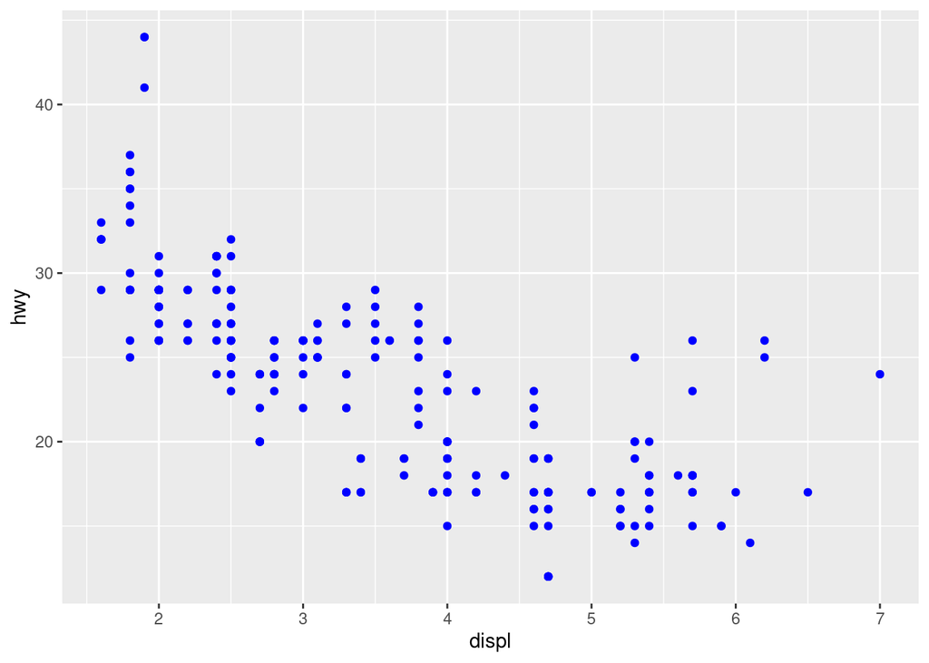

```r
ggplot(data = mpg) +
geom_point(mapping = aes(x = displ, y = hwy), color = "blue") #Set the color of all the points to blue.
```

2. Which variables in `mpg` are categorical? Which variables are continuous? (Hint: type `?mpg` in the Console Panel to read the documentation for the dataset in the Help Panel). How can you see this information when you run `mpg`?

Description:

The classification of variables is given below:

Categorical: ‘manufacture’, ‘model’, ‘trans’, ‘drv’, ‘fl’, ‘class’

Continuous: ‘displ’, ‘year’, ‘cyl’, ‘cty’, ‘hwy’

When we run ‘mpg’, the **mpg** dataset is displayed in a tabular format with the name and type of the variables in the heading. From the datatype, we can easily classify the variables as continuous or categorical.

```r
mpg
```

```
## # A tibble: 234 × 11
##    manufacturer model      displ  year   cyl trans drv     cty   hwy fl    class
##    <chr>        <chr>      <dbl> <int> <int> <chr> <chr> <int> <int> <chr> <chr>
##  1 audi         a4           1.8  1999     4 auto… f        18    29 p     comp…
##  2 audi         a4           1.8  1999     4 manu… f        21    29 p     comp…
##  3 audi         a4           2    2008     4 manu… f        20    31 p     comp…
##  4 audi         a4           2    2008     4 auto… f        21    30 p     comp…
##  5 audi         a4           2.8  1999     6 auto… f        16    26 p     comp…
##  6 audi         a4           2.8  1999     6 manu… f        18    26 p     comp…
##  7 audi         a4           3.1  2008     6 auto… f        18    27 p     comp…
##  8 audi         a4 quattro   1.8  1999     4 manu… 4        18    26 p     comp…
##  9 audi         a4 quattro   1.8  1999     4 auto… 4        16    25 p     comp…
## 10 audi         a4 quattro   2    2008     4 manu… 4        20    28 p     comp…
## # ℹ 224 more rows
```

3. Using your R code for 3.3.1.1, map a continuous variable to `color`, `size`, and `shape`. How does the aesthetic `shape` behave differently for mappings to `fl` and `displ`?

Description:

When we map the continuous variable ‘displ’ to the ‘color’ and ‘size’ aesthetics, we are able to generate a meaningful visual scatterplot.

When we try to map ‘displ’ to the ‘shape’ aesthetic, the code will generate a warning since shape aesthetic can be used only for categorical variables.

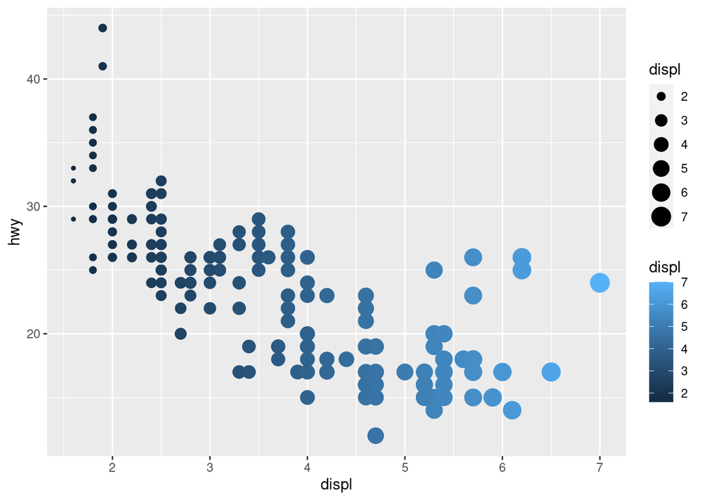

```r
ggplot(data = mpg) +
geom_point(mapping = aes(x = displ, y = hwy, color = displ, size = displ)) #Mapping a continuous variable 'displ' to color and size aesthetics
```

Mapping `displ` to `color` and `size` produce meaningful results. Mapping `displ` to `shape` produces a warning. Assigning the aesthetic `shape` to `fl` produces the following.

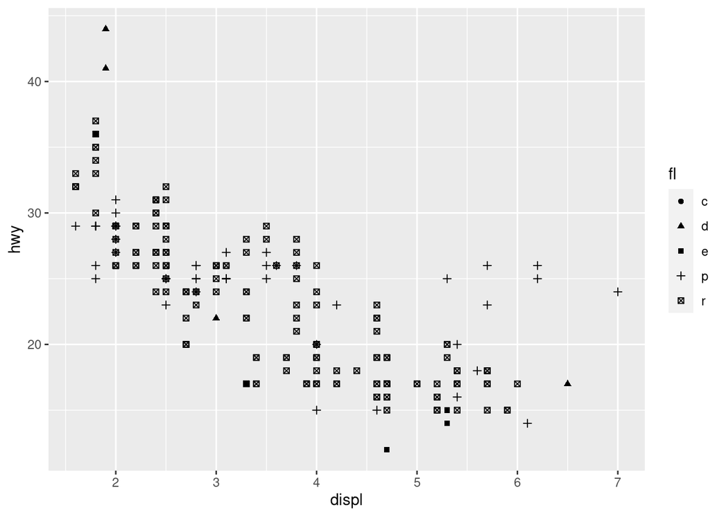

```r
ggplot(data = mpg) +
geom_point(mapping = aes(x = displ, y = hwy, shape = fl)) #Mapping 'fl' to shape aesthetic
```

4. What happens if you map the same variable to multiple aesthetics? Use an example from your answers to problem 3.3.1.3.

Description:

While mapping continuous variables to multiple aesthetics, an error will be generated for shape.

While mapping categorical variables to multiple aesthetics, a warning will be generated for size.

In both the cases, mapping the same variable to different aesthetics results in the same variable determining different visual properties of the plot elements. This can lead to confusion and visual clutter. Mapping the same variable to multiple aesthetics should be done when the resultant plot can be easily interpreted and there is visual distinction.

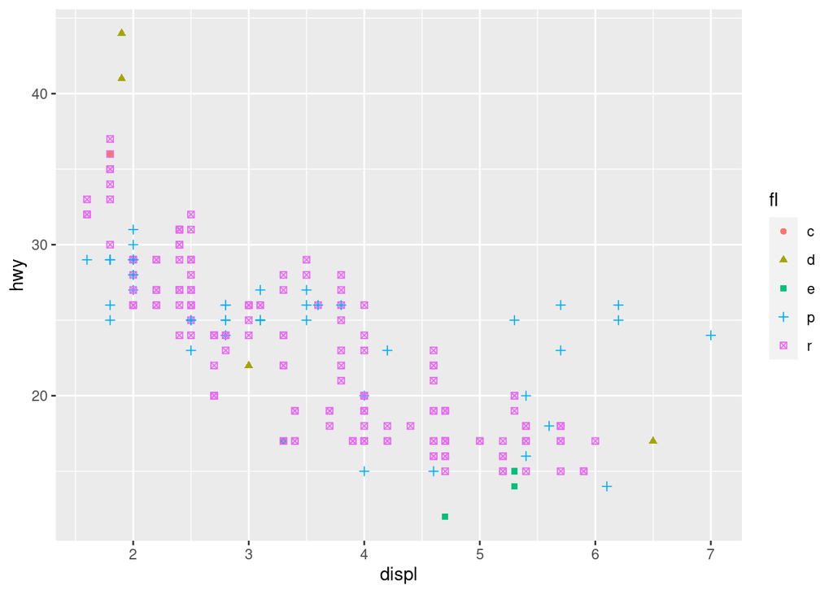

```r
#Categorical variable mapping
ggplot(data = mpg) +
geom_point(mapping = aes(x = displ, y = hwy, color = fl, shape = fl))
```

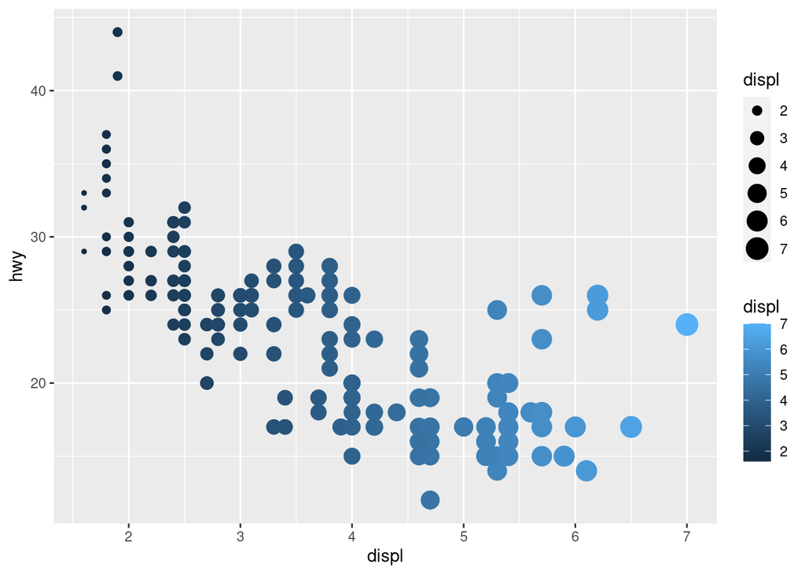

```r
#Continuous variable mapping
ggplot(data = mpg) +
geom_point(mapping = aes(x = displ, y = hwy, color = displ, size = displ))
```

5. What does the `stroke` aesthetic do? What shapes does it work with? (Hint: use`?geom_point`) Try it with `shape=21` and `stroke=displ` in your code from 3.3.1.1.

Description:

The ‘stroke’ aesthetic controls the width and color of the border of a shape in the plot. It works with shapes that have outlines like shapes 21-25. When we select ‘shape=21’, this specifies a point shape that consists of a circle with an outline.

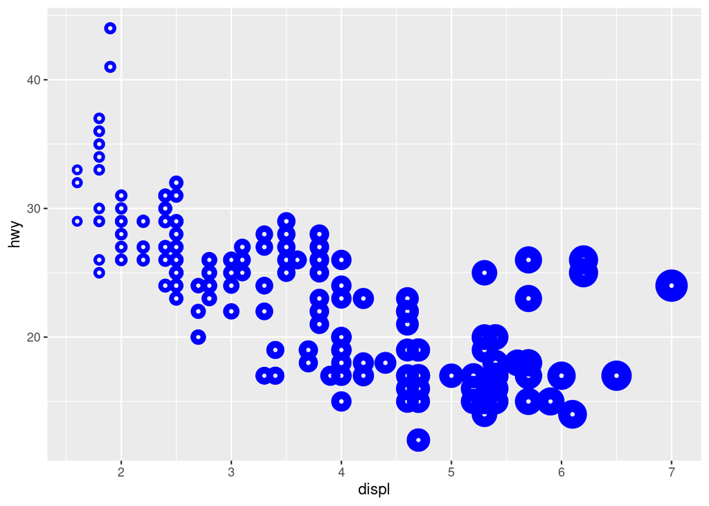

```r
ggplot(data = mpg) +
geom_point(aes(x = displ, y = hwy, stroke=displ), shape=21, color="blue")
```

6. What happens if you map an aesthetic to something other than a variable name, like `aes(colour = displ < 5)`? Try this by modifying your code in problem 3.3.1.1.

Description:

When we mao the color aesthetic to the above given expression, the ‘ggplot()’ function will map the ‘True’ and ‘False’ values to different colors. The expression results in ‘True’ when ‘displ’ is less than 5 and ‘False’ otherwise. This can be used to create visualizations that highlight specific patterns or attributes in data depending on logical conditions.

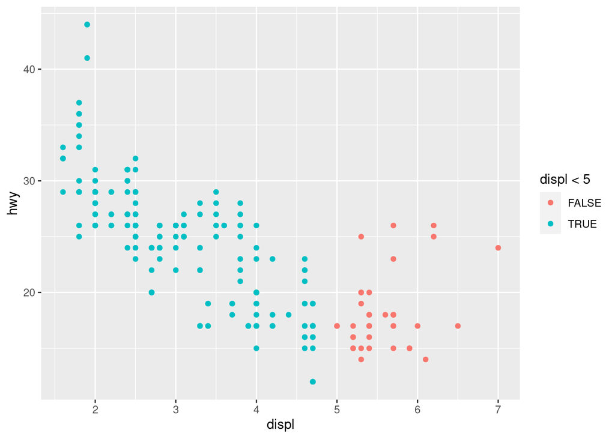

```r
ggplot(data = mpg) +
geom_point(aes(x = displ, y = hwy, colour = displ < 5))
```